# Tidy Data

June 28, 2016

## Quickie Sermon on Data Quality

Prevention Cost:

- Verifying the quality a record costs the business $1.

Correction Cost:

- Cleansing and deduplicating a record costs the business $10.

Failure Cost:

- Working with a record that’s never cleansed costs $100.

[1-10-100 Rule of Data Quality](http://www.smartdatacollective.com/martindoyle/222401/why-data-should-be-business-asset-1-10-100-rule)

## Read [Tidy Data article](http://cran.r-project.org/web/packages/tidyr/vignettes/tidy-data.html)

> Happy families are all alike; every unhappy family is unhappy in its own way

> -Leo Tolstoy, as quoted by Hadley

## Tidy Data Sets

1. Each variable forms a column
2. Each observation forms a row
3. Each data set contains rows w/ only one unit of analysis

as defined by Hadley Wickham's Tidy Data

## **Ex. of Units of Analysis**

- students within classes
- classes within degree programs
- degree programs within departments
- departments within schools
- schools within colleges (undergrad vs. grad. vs extension)
- colleges within universities

## Tidy Data Types

### For each unit,

- a text variable should be stored as text,
- a numeric variable as a number,
- and so on,

### All consistent across the data set

```r
str(dta)
```

```
## 'data.frame':    4 obs. of  5 variables:
##  $ int.var : int  1 2 3 4
##  $ char.var: chr  "A" "B" "C" "D"
##  $ log.var : logi  TRUE FALSE TRUE TRUE
##  $ date.var: Date, format: "2016-06-25" "2016-06-26" ...
##  $ num.var : num  1.5 2.3 0.667 5
```

## Untidy Data

1. Column names represent data values instead of variable names
2. A single column contains data on multiple variables instead of a single variable
3. Variables are contained in both rows and columns instead of just columns
4. A single table contains more than one observational unit
5. Data about an observational unit is spread across multiple data sets

### Notice: no.4 & 5 assume that you can

- blend/merge data sets by adding new cols
- but cannot append new rows of differing units of analysis

## Transcripts: Untidy data

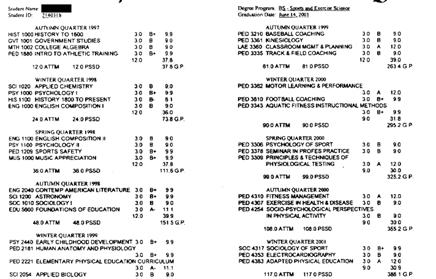

## Transcript Records: Tidy Data

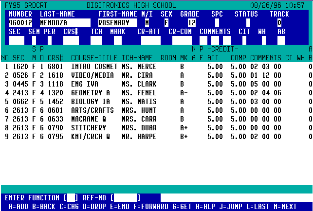

## Transcript Records: Tidy Data

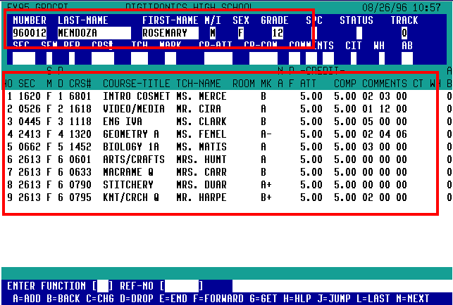

Universities have lots of Transactional Records.

Each row is one action taken by the same student over time.

## Transcript Records: Tidy

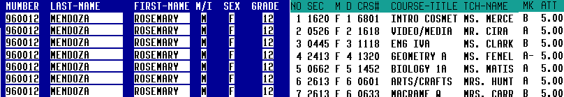

Universities have lots of Transactional Records.

Each row is one action taken by the same student over time.

## Tidy Process

1. Take `raw` data, **correct it**
2. Take `corrected` data, **make it consistent**
3. Take `consistent` data, **transform it**
4. Take `transformed` data, **merge it**
5. Take `merged` data, **analyze it**

## Stastical Analysis Value Chain

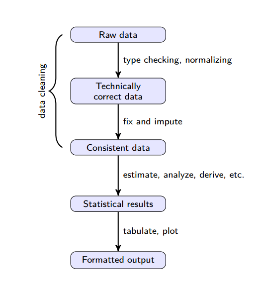

[de Jonge and van der Loo](http://cran.r-project.org/doc/contrib/de_Jonge-van_der_Loo-Introduction_to_data_cleaning_with_R.pdf)

## Tidy Recipe

1. Raw data file
2. R script contain all tidying procedures
3. Tidy data file
4. A codebook describing variables and their values
   - most university data files do not have these codebooks

### Major public services

- sharing data files across silos
- creating and sharing codebooks

## Wrangling = Explore + Tame

### To explore, we use

- table
- plot

### To tame, we use

- tidyr
- dplyr

## tidyr

In data processing, data are often represented by a combination of items (objects organized in rows), and multiple variables (organized in columns).

-Wikipedia on Data

## Tidy data

**Check if**

- Each column is a variable.
- Each row is an observation.

**Definitions**

1. *Variable*: a characteric or attribute (height, temperature, distance) of an object or item
2. *Observation*: one instance/example of an object (persons, things, places, activity)

### **SO**

- Columns should have same attribute
- Rows should be for same item/observation

## Tidyr's verb compliments

**reshape**

1. gather
2. spread

**create/join columns**

1. separate
2. unite

**extract information**

1. extract
2. extract_numeric

## Reshaping Data

```r
install.packages("tidyr")  # make sure to download package
```

```r
library(tidyr)      # remember to attach tidyr
library(dplyr)      # tidyr and dplyr often woven together
```

```r
str(gather)         # basic syntax of gather
```

```
## function (data, key, value, ..., na.rm = FALSE, convert = FALSE, factor_key = FALSE)
```

```r
str(spread)         # basic syntax of spread
```

```
## function (data, key, value, fill = NA, convert = FALSE, drop = TRUE,
##     sep = NULL)
```

## `gather()`

takes multiple columns, and gathers them into key-value pairs: it makes “wide” data longer.

Other names for `gather()` include

- melt (reshape2, pandas)
- pivot (spreadsheets)
- fold (databases)

–[rstudio blog](http://blog.rstudio.org/2014/07/22/introducing-tidyr/)

## Ex.: gather()

We have data frame w/ 4 students who each received counseling services from

- academic affairs (acad_aff)
- student affairs (stud_aff).

**Under each service**, we have its reported helpfulness score: 1-10.

```r
did_help
```

```
## Source: local data frame [4 x 3]
##
##   students acad_aff stud_aff
##      (chr)    (dbl)    (dbl)
## 1     Mick        3        4
## 2  Celeste        9        7
## 3   Benton        6        8
## 4     Lisa        7        4
```

- How is this data not tidy? How would you fix it?

## Ex.: gather(), why untidy?

```r
str(did_help)   # for starters, check data frame properties
```

```
## Classes 'tbl_df', 'tbl' and 'data.frame':    4 obs. of  3 variables:
##  $ students: chr  "Mick" "Celeste" "Benton" "Lisa"
##  $ acad_aff: num  3 9 6 7
##  $ stud_aff: num  4 7 8 4
```

### Operative phrase = "Under each service"

We have the same attribute in two separate variables for same person

- col for acad helpfulness scores
- col for stud helpfulness scores

## Ex.: gather(), going tall

**SHOULD BE**: Gather scores by service

- vars for services and for scores

```r
# model : gather(data, col_names_as_key, col_vals_as_values, columns_to_gather)
gather(did_help,                # data to use
       service,                 # var name for service key
       helpful_score,           # var name for scores values
       acad_aff:stud_aff)       # columns to gather
```

```
## Source: local data frame [8 x 3]
##
##   students  service helpful_score
##      (chr)    (chr)         (dbl)
## 1     Mick acad_aff             3
## 2  Celeste acad_aff             9
## 3   Benton acad_aff             6
## 4     Lisa acad_aff             7
## 5     Mick stud_aff             4
## 6  Celeste stud_aff             7
## 7   Benton stud_aff             8
## 8     Lisa stud_aff             4
```

## Ex: `spread()`

We have a data.frame containing students' GPA, Rank, & Major:

```r
stud.file
```

```
## Source: local data frame [9 x 3]
##
##   stud.no info.type info.value
##     (chr)     (chr)      (chr)
## 1  181012       GPA       3.22
## 2  181012      Rank        144
## 3  181012     Major  Chemistry
## 4  140763       GPA       3.78
## 5  140763      Rank         98
## 6  140763     Major    PoliSci
## 7  143763       GPA       3.48
## 8  143763      Rank         88
## 9  143763     Major    PoliSci
```

### Take 30 sec

- How is this data not tidy? How would you tidy it?

## Ex: `spread()`, why untidy?

```r
str(stud.file)    # for starters, check data frame properties
```

```
## Classes 'tbl_df', 'tbl' and 'data.frame':    9 obs. of  3 variables:
##  $ stud.no   : chr  "181012" "181012" "181012" "140763" ...
##  $ info.type : chr  "GPA" "Rank" "Major" "GPA" ...
##  $ info.value: chr  "3.22" "144" "Chemistry" "3.78" ...
```

1. Everything is a character
2. info.value is not a variable. We have three different class types
- GPA = numeric
- Rank = integer
- Major = factor
1. columns do not have common data type

## Ex: `spread()`, going wide

```r
# model : spread(data, key, value)
s2  <- spread(stud.file, info.type, info.value)   # go wide
s2                                                # forgot stringsAsFactors=F
```

```
## Source: local data frame [3 x 4]
##
##   stud.no   GPA     Major  Rank
##     (chr) (chr)     (chr) (chr)
## 1  140763  3.78   PoliSci    98
## 2  143763  3.48   PoliSci    88
## 3  181012  3.22 Chemistry   144
```

```r
str(s2)
```

```
## Classes 'tbl_df' and 'data.frame':   3 obs. of  4 variables:
##  $ stud.no: chr  "140763" "143763" "181012"
##  $ GPA    : chr  "3.78" "3.48" "3.22"
##  $ Major  : chr  "PoliSci" "PoliSci" "Chemistry"
##  $ Rank   : chr  "98" "88" "144"
```

## coerce to correct class type

```r
s2$GPA         <- as.numeric(s2$GPA)       # set GPA as numeric
s2[,3]         <- factor(    s2$Major)     # set Major as factor
s2[ , "Rank"]  <- as.integer(s2$Rank)      # set Rank as integer
str(s2)
```

```
## Classes 'tbl_df' and 'data.frame':   3 obs. of  4 variables:
##  $ stud.no: chr  "140763" "143763" "181012"
##  $ GPA    : num  3.78 3.48 3.22
##  $ Major  : Factor w/ 2 levels "Chemistry","PoliSci": 2 2 1
##  $ Rank   : int  98 88 144
```

```r
s2
```

```
## Source: local data frame [3 x 4]
##
##   stud.no   GPA     Major  Rank
##     (chr) (dbl)    (fctr) (int)
## 1  140763  3.78   PoliSci    98
## 2  143763  3.48   PoliSci    88
## 3  181012  3.22 Chemistry   144
```

## Now can do it in one step

```r
spread(stud.file, info.type, info.value, convert=TRUE)
```

```
## Source: local data frame [3 x 4]
##
##   stud.no   GPA     Major  Rank
##     (chr) (dbl)     (chr) (int)
## 1  140763  3.78   PoliSci    98
## 2  143763  3.48   PoliSci    88
## 3  181012  3.22 Chemistry   144
```

## Ex: unite, col names w/ compound information

```r
yr_enroll
```

```
## Source: local data frame [21 x 7]
##
##     year engl.101 engl.102 math.101 math.102 educ.101 educ.102
##    (int)    (dbl)    (int)    (int)    (int)    (int)    (dbl)
## 1   1990       14       51       51       45       48       12
## 2   1991       16       31       39       31       23       10
## 3   1992       20       55       38       49       45       18
## 4   1993       27       49       48       40       19       27
## 5   1994       12       44       15       28       24       20
## 6   1995       26       60       34       57       56       28
## 7   1996       26       45       44       25       58       22
## 8   1997       29       27       42       47       16       14
## 9   1998       19       48       33       29       38       16
## 10  1999        8       43       46       48       46       30
## ..   ...      ...      ...      ...      ...      ...      ...
```

## Task: tidy yr_enrollments

We need to gather the data into columns for

- dept
- class level
- enrollments

```r
yr_long_enroll <- gather(yr_enroll,                   # data_frame
                         dept_level, enrollments,     # key, value
                         -year)                       # var not to gather
yr_long_enroll
```

```
## Source: local data frame [126 x 3]
##
##     year dept_level enrollments
##    (int)      (chr)       (dbl)
## 1   1990   engl.101          14
## 2   1991   engl.101          16
## 3   1992   engl.101          20
## 4   1993   engl.101          27
## 5   1994   engl.101          12
## 6   1995   engl.101          26
## 7   1996   engl.101          26
## 8   1997   engl.101          29
## 9   1998   engl.101          19
## 10  1999   engl.101           8
## ..   ...        ...         ...
```

## separate multiple values within single column

### break at non-alphanumeric, default

```r
yr <- separate(yr_long_enroll,
           dept_level,
           c("dept","level")
           )
yr
```

```
## Source: local data frame [126 x 4]
##
##     year  dept level enrollments
##    (int) (chr) (chr)       (dbl)
## 1   1990  engl   101          14
## 2   1991  engl   101          16
## 3   1992  engl   101          20
## 4   1993  engl   101          27
## 5   1994  engl   101          12
## 6   1995  engl   101          26
## 7   1996  engl   101          26
## 8   1997  engl   101          29
## 9   1998  engl   101          19
## 10  1999  engl   101           8
## ..   ...   ...   ...         ...
```

### break at character position

```r
long_enroll <- separate(yr_long_enroll,
             dept_level,
             c("dept","level"),
      4)  # break after 4 character
long_enroll
```

```
## Source: local data frame [126 x 4]
##
##     year  dept level enrollments
##    (int) (chr) (chr)       (dbl)
## 1   1990  engl  .101          14
## 2   1991  engl  .101          16
## 3   1992  engl  .101          20
## 4   1993  engl  .101          27
## 5   1994  engl  .101          12
## 6   1995  engl  .101          26
## 7   1996  engl  .101          26
## 8   1997  engl  .101          29
## 9   1998  engl  .101          19
## 10  1999  engl  .101           8
## ..   ...   ...   ...         ...
```

## unite(), create key for spread()

- Step 1: unite key by joining 2 cols

```r
yr <- unite(yr, dept_level,
            c(dept, level))
yr
```

```
## Source: local data frame [126 x 3]
##
##     year dept_level enrollments
##    (int)      (chr)       (dbl)
## 1   1990   engl_101          14
## 2   1991   engl_101          16
## 3   1992   engl_101          20
## 4   1993   engl_101          27
## 5   1994   engl_101          12
## 6   1995   engl_101          26
## 7   1996   engl_101          26
## 8   1997   engl_101          29
## 9   1998   engl_101          19
## 10  1999   engl_101           8
## ..   ...        ...         ...
```

## unite(), create key for spread()

- Step 2: spread data using key:value pairs

```r
yr_wide <- spread(yr, dept_level,
                  enrollments )
yr_wide
```

```
## Source: local data frame [21 x 7]
##
##     year educ_101 educ_102 engl_101 engl_102 math_101 math_102
##    (int)    (dbl)    (dbl)    (dbl)    (dbl)    (dbl)    (dbl)
## 1   1990       48       12       14       51       51       45
## 2   1991       23       10       16       31       39       31
## 3   1992       45       18       20       55       38       49
## 4   1993       19       27       27       49       48       40
## 5   1994       24       20       12       44       15       28
## 6   1995       56       28       26       60       34       57
## 7   1996       58       22       26       45       44       25
## 8   1997       16       14       29       27       42       47
## 9   1998       38       16       19       48       33       29
## 10  1999       46       30        8       43       46       48
## ..   ...      ...      ...      ...      ...      ...      ...
```

## extract_numeric

```r
income <- data_frame( person = 1:5,
                      amount = c("2000 bucks", "$1500", "250.58",
                               "5,000", "about 300 dollars")     )
round(extract_numeric(income$amount), 0)         # pulls out the numerics
```

```
## [1] 2000 1500  251 5000  300
```

## extract for regex

```r
df <- data.frame(x = c(NA, "a-b", "a-d", "b-c", "d-e"))
df %>% extract(x, c("A", "B"), "([[:alnum:]]+)-([[:alnum:]]+)")
```

```
##      A    B
## 1 <NA> <NA>
## 2    a    b
## 3    a    d
## 4    b    c
## 5    d    e
```

```r
df %>% extract(x, c("A", "B"), "([a-d]+)-([a-d]+)")
```

```
##      A    B
## 1 <NA> <NA>
## 2    a    b
## 3    a    d
## 4    b    c
## 5 <NA> <NA>
```